# R Notebook

```r
 library(tidyverse)
```

```r
library(CodeClanData)
library(ggplot2)
```

2 MVP 2.1 Part 1 Question 1. Take the data in the dataset qb_revenue_breakdown and make a stacked bar chart showing the sources of revenue across the two years in the dataset.

```r
qb_revenue_breakdown
```

| Product | Year | Revenue |
| --- | --- | --- |
| Trackers | 2019 | 8994 |
| Smart Watches | 2019 | 12003 |
| Accessories | 2019 | 5250 |
| Subscription Services | 2019 | 3750 |
| Trackers | 2018 | 8004 |
| Smart Watches | 2018 | 11000 |
| Accessories | 2018 | 4250 |
| Subscription Services | 2018 | 1005 |

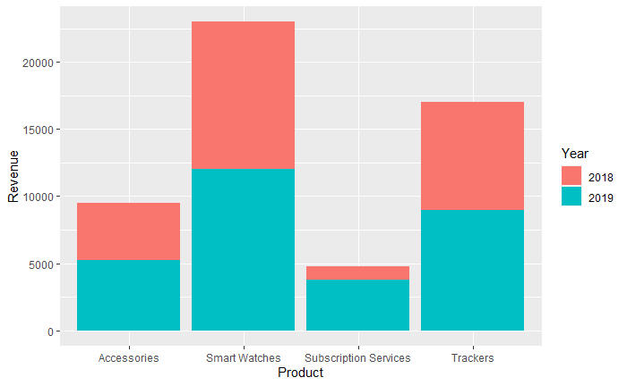

```r
qb_revenue_breakdown %>%
  ggplot(aes(x = Product, y = Revenue, fill = Year)) +
              geom_col()
```

Question 2. Make a line chart showing monthly sales of the “flagship product” - the ‘KwikBit Unit 1’ - over the last year. This data is inside qb_monthly_sales, but you will need to use filter() or subset() (base R).

```r
qb_monthly_sales
```

| Date | Cashflow | Amount |
| --- | --- | --- |
| 2019-07-01 | Kwikbit Unit 1 Sales | 601.74 |
| 2019-06-01 | Kwikbit Unit 1 Sales | 567.89 |
| 2019-05-01 | Kwikbit Unit 1 Sales | 536.00 |
| 2019-04-01 | Kwikbit Unit 1 Sales | 550.78 |
| 2019-03-01 | Kwikbit Unit 1 Sales | 526.03 |
| 2019-02-01 | Kwikbit Unit 1 Sales | 584.22 |
| 2019-01-01 | Kwikbit Unit 1 Sales | 530.76 |
| 2018-12-01 | Kwikbit Unit 1 Sales | 504.80 |
| 2018-11-01 | Kwikbit Unit 1 Sales | 513.67 |
| 2018-10-01 | Kwikbit Unit 1 Sales | 499.99 |

[output cut: 26 more lines]

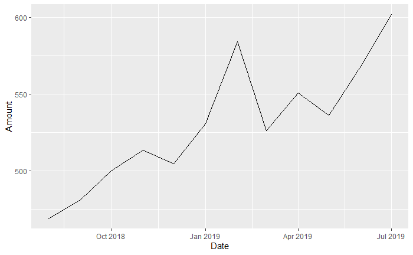

```r
qb_monthly_sales %>%
  filter(Cashflow == 'Kwikbit Unit 1 Sales') %>%
  ggplot(aes(x = Date, y = Amount))+
  geom_line()
```

Question 3. Make a line chart showing monthly revenue and costs over the last year. This data is also in qb_monthly_sales.

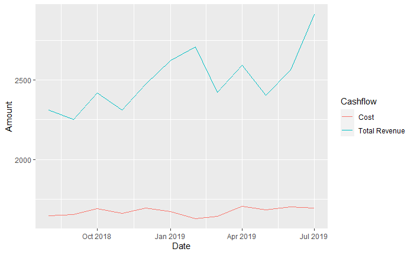

```r
qb_monthly_sales %>%
  filter(Cashflow == 'Total Revenue'| Cashflow == 'Cost') %>%
  ggplot(aes(x = Date, y = Amount, group = Cashflow))+
  geom_line(aes(colour = Cashflow))
```

```r
NA
NA
```

Question 4. Show annual sales of personal fitness trackers over the last 5 years broken down by company as a ribbon plot (use geom_area). This data is in qb_competitors.

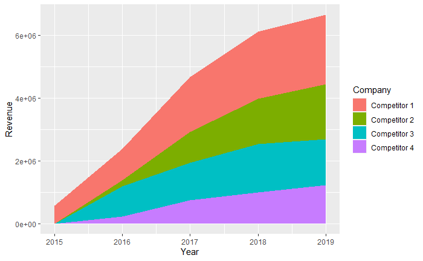

Question 5. Now show the sales from the four competitors as a line graph. Include an extra layer that shows the data points used to make the lines.

```r
qb_competitors
```

| Company | Year | Revenue |
| --- | --- | --- |
| Competitor 1 | 2019 | 2216000 |
| Competitor 2 | 2019 | 1760000 |
| Competitor 3 | 2019 | 1455000 |
| Competitor 4 | 2019 | 1229000 |
| Competitor 1 | 2018 | 2144400 |
| Competitor 2 | 2018 | 1440000 |
| Competitor 3 | 2018 | 1555000 |
| Competitor 4 | 2018 | 987000 |
| Competitor 1 | 2017 | 1750000 |
| Competitor 2 | 2017 | 987000 |

[output cut: 10 more lines]

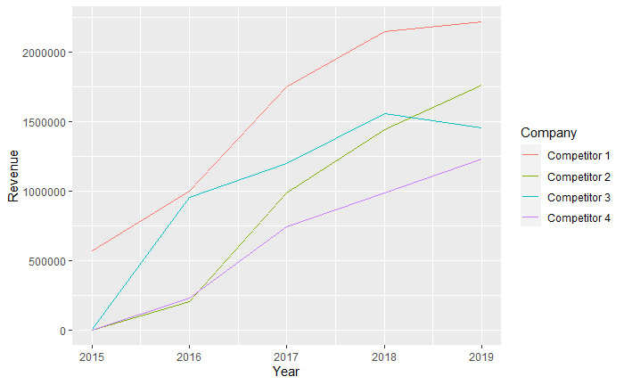

```r
qb_competitors %>%
  ggplot(aes(x = Year, y = Revenue, group = Company)) +
  geom_line(aes(colour = Company))
```

Question 6. Now the company wants to compare the number of steps that their device counts vs. their competitors. Make a line graph of the number of steps throughout time, and use faceting to compare between companies and people. The data for this is in qb_device_data.

```r
device <- qb_device_data
```

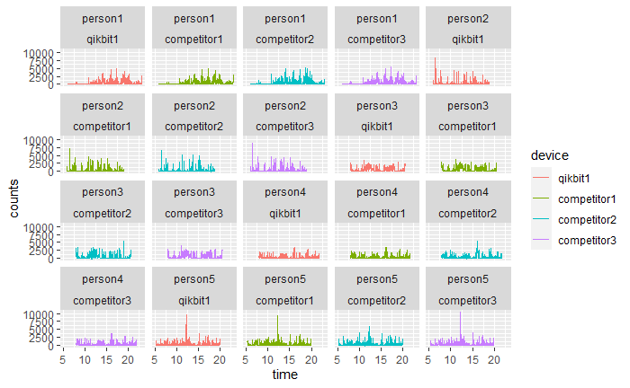

```r
device %>%
  mutate(time = hours + mins/60) %>%
  ggplot(aes(x = time , y = counts, colour = device ))+
  geom_line()+
  facet_wrap(id~device)
```

2.2 Part 2 Question 1. Take the plots that you produced in part one and now polish them by: Adding appropriate labels Changing the scales and coordinates when appropriate. Applying a unified theme, which is described below: Graphs should have white backgrounds, and use colour sparingly. There should be faint grid lines. Font sizes should be ~12pt although titles should be slightly larger and axis labels can be slightly smaller. All plots should use colours from the following company colour scheme.

```r
# company_theme <- theme %>%
# (plot.title = element_text(size = 12,face = "bold"),panel.background = element_rect(fill = "white"),axis.text.x = element_text(angle = 45, hjust = 1))
```

q1

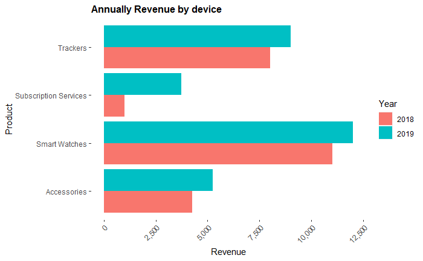

Q2

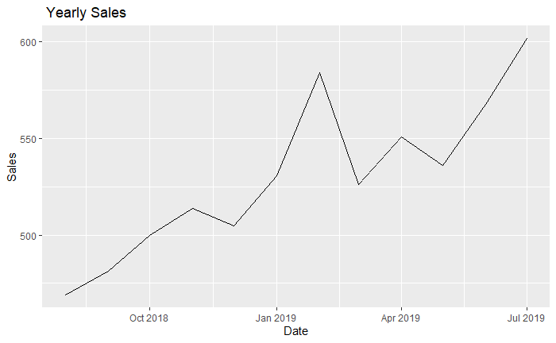

```r
qb_monthly_sales %>%
  filter(Cashflow == 'Kwikbit Unit 1 Sales') %>%
  ggplot(aes(x = Date, y = Amount))+
  labs(y = 'Sales', title = ' Yearly Sales' )+
  geom_line()
```

q3

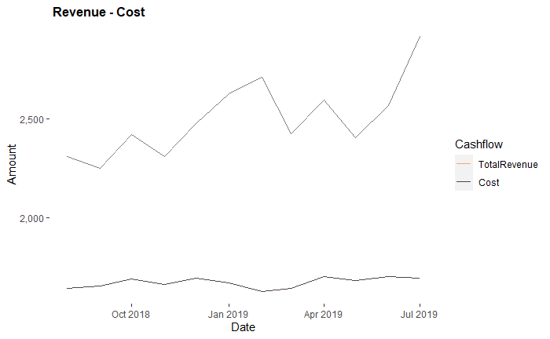

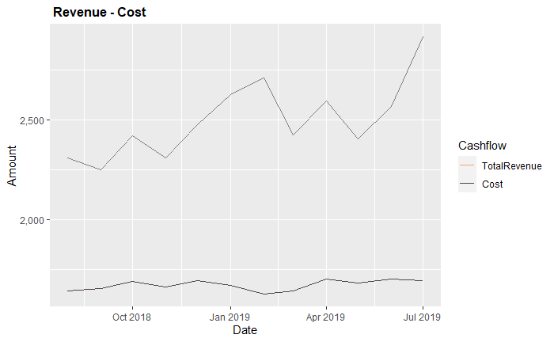

Q4

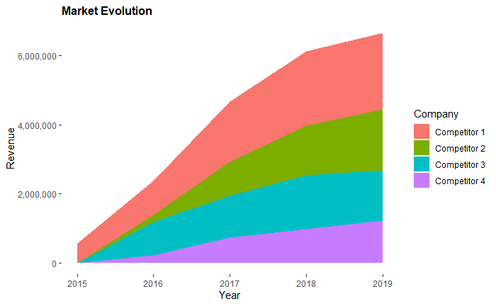

Q5

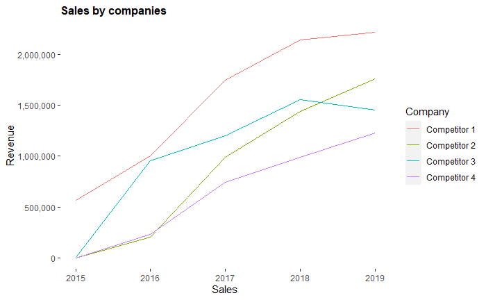

Q6

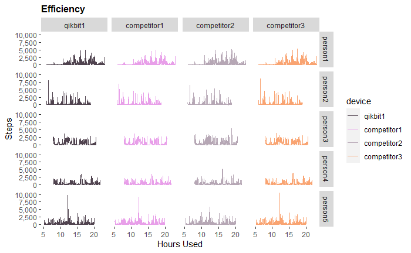